# RPUBS

Tipologia i cicle de vida de les dades

Jordi Dil i Giró & Carlota Font Castell

20 de diciembre, 2020

# 1 Introducció

El naufragi del RMS Titànic és un dels esdeveniments més famosos de la història del segle XX. El dia 15 d’abril del 1912 el Titànic es va enfonsar després de xocar amb un iceberg al mig de l’atlàntic, mentre navegava d’Anglaterra cap a Nova York. En aquest naufragi van morir 1.502 persones de 2.224 passatgers i tripulació. Una de les raons principals de la mort de tants passatgers va ser la manca de bots salvavides. És per això que es va haver de fer una sel·lecció de passatgers, pel que alguns van tenir una probabilitat més alta de supervivència que altres.

A conseqüència d’aquest desastre, es van implementar regulacions molt estrictes per tal de reforçar la seguretat dels vaixells.

## 1.1 Objectius del projecte

L’objectiu del projecte és analitzar quin grup de passatgers tenia més probabilitat de supervivència, així utilitzant algoritmes de Machine Learning. A més a més, el model hauria de ser capaç de prediure si un passatger sobreviuria o no al Titànic.

# 2 Dades

Les dades utilitzades han estat descarregades del Kaggle. Més informació en relació a les dades i les seves variables es pot trobar en el .pdf del GitHub.

## 2.1 Càrrega de llibreries i dades

```r
# Pujada de les llibreries necessàries per l'execució del codi
# Manipulació de dades
library(dplyr)
```

```r
# Visualització de dades
library(ggplot2)
# Imputació de dades perdudes, NA o en blanc
library(mice)
# Classificació d'algoritmes
library(randomForest)
library(rpart)
# Visualització de l'arbre de decisió
library(rpart.plot)
# Divisió de dades en train i test
library(caTools)
library(oddsratio)
library(GGally)
library(caret)
# Pujada dels fitxers train i test
train <- read.csv("./fitxers/train.csv", sep = ",", stringsAsFactors = FALSE)
test <- read.csv("./fitxers/test.csv", sep=",", stringsAsFactors = FALSE)

# Afegim el camp file_origin per tenir una traçabilitat ràpida
train$file_origin = 'train'
test$file_origin = 'test'

# Creem un sol data set
ds_titanic <- bind_rows(train, test)

# Mirem l'estructura de les dades
str(ds_titanic)
```

```
## 'data.frame':    1309 obs. of  13 variables:
##  $ PassengerId: int  1 2 3 4 5 6 7 8 9 10 ...
##  $ Survived   : int  0 1 1 1 0 0 0 0 1 1 ...
##  $ Pclass     : int  3 1 3 1 3 3 1 3 3 2 ...
##  $ Name       : chr  "Braund, Mr. Owen Harris" "Cumings, Mrs. John Bradley (Florence Briggs Thayer)" "Heikkinen, Miss. Laina" "Futrelle, Mrs. Jacques Heath (Lily May Peel)" ...
##  $ Sex        : chr  "male" "female" "female" "female" ...
##  $ Age        : num  22 38 26 35 35 NA 54 2 27 14 ...
##  $ SibSp      : int  1 1 0 1 0 0 0 3 0 1 ...
##  $ Parch      : int  0 0 0 0 0 0 0 1 2 0 ...
##  $ Ticket     : chr  "A/5 21171" "PC 17599" "STON/O2. 3101282" "113803" ...
##  $ Fare       : num  7.25 71.28 7.92 53.1 8.05 ...
##  $ Cabin      : chr  "" "C85" "" "C123" ...
##  $ Embarked   : chr  "S" "C" "S" "S" ...
##  $ file_origin: chr  "train" "train" "train" "train" ...
```

```r
# Resum de les dades
summary(ds_titanic)
```

```
##   PassengerId      Survived          Pclass          Name
##  Min.   :   1   Min.   :0.0000   Min.   :1.000   Length:1309
##  1st Qu.: 328   1st Qu.:0.0000   1st Qu.:2.000   Class :character
##  Median : 655   Median :0.0000   Median :3.000   Mode  :character
##  Mean   : 655   Mean   :0.3838   Mean   :2.295
##  3rd Qu.: 982   3rd Qu.:1.0000   3rd Qu.:3.000
##  Max.   :1309   Max.   :1.0000   Max.   :3.000
##                 NA's   :418
##      Sex                 Age            SibSp            Parch
##  Length:1309        Min.   : 0.17   Min.   :0.0000   Min.   :0.000
##  Class :character   1st Qu.:21.00   1st Qu.:0.0000   1st Qu.:0.000
##  Mode  :character   Median :28.00   Median :0.0000   Median :0.000
##                     Mean   :29.88   Mean   :0.4989   Mean   :0.385
##                     3rd Qu.:39.00   3rd Qu.:1.0000   3rd Qu.:0.000
##                     Max.   :80.00   Max.   :8.0000   Max.   :9.000
##                     NA's   :263
##     Ticket               Fare            Cabin             Embarked
##  Length:1309        Min.   :  0.000   Length:1309        Length:1309
##  Class :character   1st Qu.:  7.896   Class :character   Class :character
##  Mode  :character   Median : 14.454   Mode  :character   Mode  :character
##                     Mean   : 33.295
##                     3rd Qu.: 31.275
##                     Max.   :512.329
##                     NA's   :1
##  file_origin
##  Length:1309
##  Class :character
##  Mode  :character
##
##
##
##
```

```r
# Mirem les primeres observacions del dataset i comprovem que s'han pujat bé
head(ds_titanic)
```

```
##   PassengerId Survived Pclass
## 1           1        0      3
## 2           2        1      1
## 3           3        1      3
## 4           4        1      1
## 5           5        0      3
## 6           6        0      3
##                                                  Name    Sex Age SibSp Parch
## 1                             Braund, Mr. Owen Harris   male  22     1     0
## 2 Cumings, Mrs. John Bradley (Florence Briggs Thayer) female  38     1     0
## 3                              Heikkinen, Miss. Laina female  26     0     0
## 4        Futrelle, Mrs. Jacques Heath (Lily May Peel) female  35     1     0
## 5                            Allen, Mr. William Henry   male  35     0     0
## 6                                    Moran, Mr. James   male  NA     0     0
##             Ticket    Fare Cabin Embarked file_origin
## 1        A/5 21171  7.2500              S       train
## 2         PC 17599 71.2833   C85        C       train
## 3 STON/O2. 3101282  7.9250              S       train
## 4           113803 53.1000  C123        S       train
## 5           373450  8.0500              S       train
## 6           330877  8.4583              Q       train
```

Veiem que hi ha 1309 observacions amb 13 variables. Els noms de les variables són:

“PassengerId” “Survived” “Pclass” “Name” “Sex”  
“Age” “SibSp” “Parch” “Ticket” “Fare”  
“Cabin” “Embarked” “file_origin”

# 3 Anàlisi exploratori de les dades

## 3.1 Dades duplicades

Validem si existeixen valor duplicats, a través de l’ID del passatger, ja que és la variable distintiva (primary key) dins del data set

```r
ds_titanic[duplicated(ds_titanic$PassengerId),]
```

```
##  [1] PassengerId Survived    Pclass      Name        Sex         Age
##  [7] SibSp       Parch       Ticket      Fare        Cabin       Embarked
## [13] file_origin
## <0 rows> (or 0-length row.names)
```

Veiem que no existeixen valors duplicats

## 3.2 Valors perduts, NA o en blanc

```r
# Mirem si hi ha algun valor NA, perdut o en blanc
any(!complete.cases(ds_titanic))
```

```
## [1] TRUE
```

Com que retorna “TRUE”, vol dir que sí que existeixen. Per tant, mirem de quines variables venen.

```r
na_count <- sapply(ds_titanic, function(x) sum(length(which(is.na(x)))))
missing <- sapply(ds_titanic, function(x) sum(length(which(x==""))))
data.frame(missing, na_count)
```

```
##             missing na_count
## PassengerId       0        0
## Survived          0      418
## Pclass            0        0
## Name              0        0
## Sex               0        0
## Age               0      263
## SibSp             0        0
## Parch             0        0
## Ticket            0        0
## Fare              0        1
## Cabin          1014        0
## Embarked          2        0
## file_origin       0        0
```

Les variables que contenen valors perduts o NA són Survived, Age, Fare, Cabin i Embarked. Tal i com es descriu a .pdf, no és sorprenent que la variable Survived contingui valors NA, ja que aquest atribut no existeix en el fitxer original “test.csv”. Pel que fa a les altres variables, buscarem una solució per eliminar aquests valors NA.

## 3.3 Visualitzacions gràfiques

### 3.3.1 Survival en funció de Age

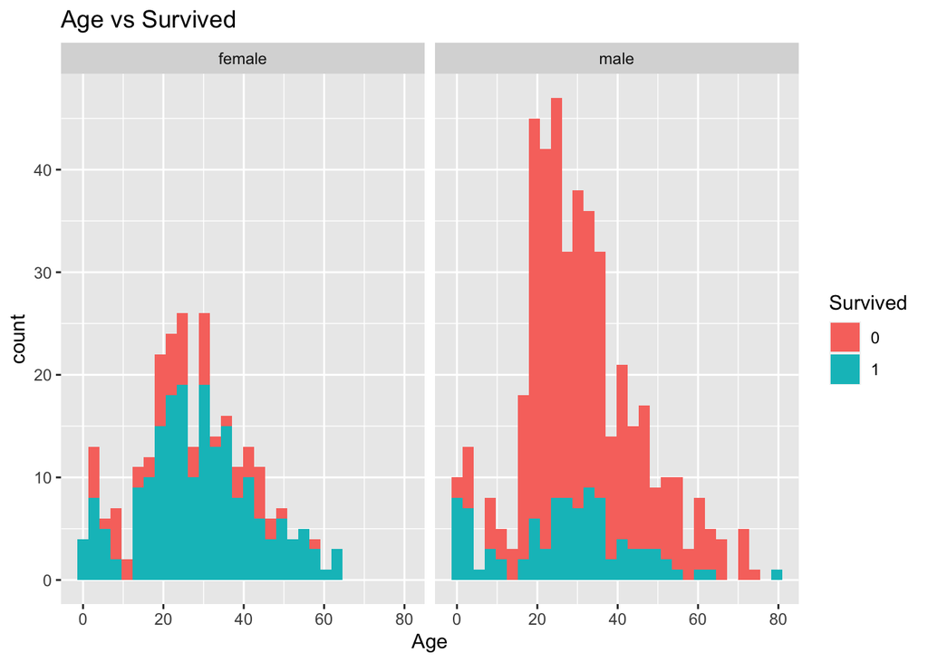

```r
ds_titanic_train <- ds_titanic[ which(ds_titanic$file_origin=='train'), ]
ds_titanic_test <- ds_titanic[ which(ds_titanic$file_origin=='test'), ]

ggplot(ds_titanic_train, aes(x=Age, fill=factor(Survived))) +
  geom_histogram(bins=30)+
  facet_grid(.~Sex)+
  ggtitle("Age vs Survived")+
  scale_fill_discrete(name="Survived")
```

La probabilitat de supervivència en dones és major que en homes. Dins del gendre homes, els que estaven per sota de 18 anys tenien una major probabitat de supervivència.

### 3.3.2 Survival en funció de Sex

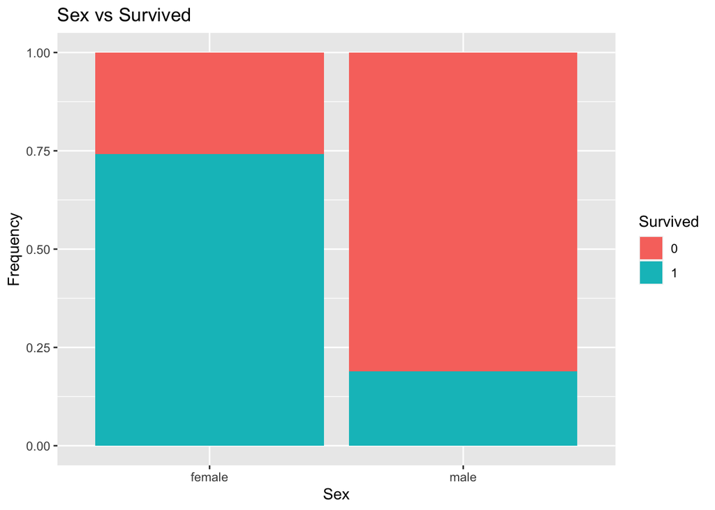

```r
ggplot(ds_titanic_train, aes(Sex, fill = factor(Survived))) +
  geom_bar(position = 'fill')+
  xlab("Sex") +
  ylab("Frequency") +
  scale_fill_discrete(name = "Survived") +
  ggtitle("Sex vs Survived")
```

Les dones van tenir un 75% de ratio de supervivència mentre que en el cas dels homes el ratio va ser < 25%.

## 3.4 Survival en funció de Pclass

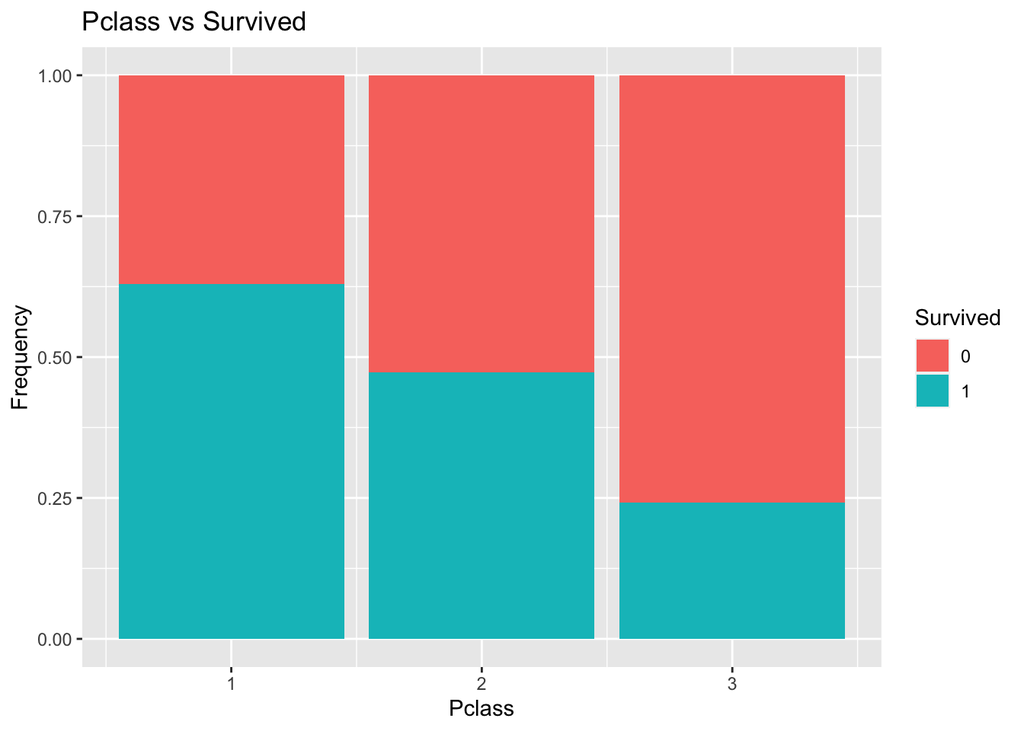

```r
ggplot(ds_titanic_train, aes(x=Pclass, fill=factor(Survived))) +
  geom_bar(position="fill")+
  ylab("Frequency")+
  scale_fill_discrete(name="Survived")+
  ggtitle("Pclass vs Survived")
```

S’observa com els passatgers de Primera Classe tenen un ratio de supervivència superior al 50%, mentre que els de segona tenen un ratio al voltant del 50%. Per altre costat, els de tercera classe tenien una probabilitat del 25%.

### 3.4.1 Survival en funció de Fare

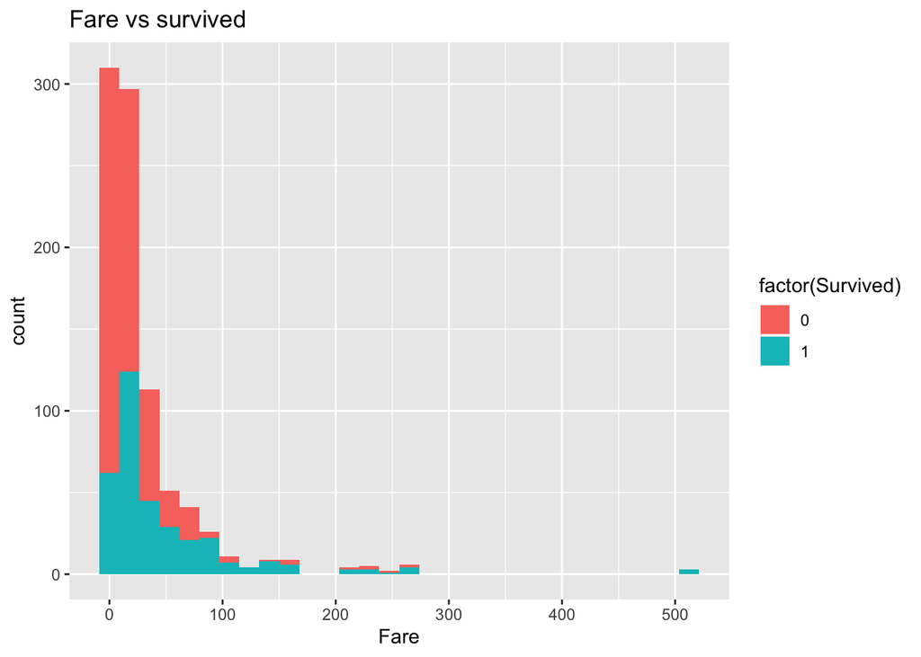

```r
ggplot(ds_titanic_train, aes(x=Fare, fill=factor(Survived)))+
  geom_histogram()+
  ggtitle("Fare vs survived")
```

Sembla que hi ha una forta correlació entre fare i taxa de supervivència. Aquells passatgers que van pagar menys de 50GBP tenien una taxa de supervivència inferior al 50%. A mesura que el passatger va pagar un ticket amb un preu més elevat, la taxa de supervivència augmenta.

# 4 Creació de noves variables

## 4.1 Títol del passatger

El títol del passatger només es pot derivar a partir del seu nom.

```r
# Observem algunes observacions de la variable Name
head(ds_titanic$Name)
```

```
## [1] "Braund, Mr. Owen Harris"
## [2] "Cumings, Mrs. John Bradley (Florence Briggs Thayer)"
## [3] "Heikkinen, Miss. Laina"
## [4] "Futrelle, Mrs. Jacques Heath (Lily May Peel)"
## [5] "Allen, Mr. William Henry"
## [6] "Moran, Mr. James"
```

A partir del nom, en derivem el seu títol

```r
ds_titanic$Title<-gsub("^.*, (.*?)\\..*$", "\\1", ds_titanic$Name)
unique(ds_titanic$Title)
```

```
##  [1] "Mr"           "Mrs"          "Miss"         "Master"       "Don"
##  [6] "Rev"          "Dr"           "Mme"          "Ms"           "Major"
## [11] "Lady"         "Sir"          "Mlle"         "Col"          "Capt"
## [16] "the Countess" "Jonkheer"     "Dona"
```

En total tenim 18 Títols diferents.

```r
# Resumim els títols pel gendre
table(ds_titanic$Sex,ds_titanic$Title)
```

```
##
##          Capt Col Don Dona  Dr Jonkheer Lady Major Master Miss Mlle Mme  Mr Mrs
##   female    0   0   0    1   1        0    1     0      0  260    2   1   0 197
##   male      1   4   1    0   7        1    0     2     61    0    0   0 757   0
##
##           Ms Rev Sir the Countess
##   female   2   0   0            1
##   male     0   8   1            0
```

Com que hi ha molts títols, els podem agrupar.

```r
ds_titanic$Title[ds_titanic$Title == 'Mlle'] <- 'Miss'
ds_titanic$Title[ds_titanic$Title == 'Ms'] <- 'Miss'
ds_titanic$Title[ds_titanic$Title == 'Mme'] <- 'Mrs'
ds_titanic$Title[ds_titanic$Title == 'Lady'] <- 'Miss'
ds_titanic$Title[ds_titanic$Title == 'Dona'] <- 'Miss'

ds_titanic$Title[ds_titanic$Title == 'Capt'] <- 'Officer'
ds_titanic$Title[ds_titanic$Title == 'Col'] <- 'Officer'
ds_titanic$Title[ds_titanic$Title == 'Major'] <- 'Officer'
ds_titanic$Title[ds_titanic$Title == 'Dr'] <- 'Officer'
ds_titanic$Title[ds_titanic$Title == 'Rev'] <- 'Officer'
ds_titanic$Title[ds_titanic$Title == 'Don'] <- 'Officer'
ds_titanic$Title[ds_titanic$Title == 'Sir'] <- 'Officer'
ds_titanic$Title[ds_titanic$Title == 'the Countess'] <- 'Officer'
ds_titanic$Title[ds_titanic$Title == 'Jonkheer'] <- 'Officer'

# Resum
table(ds_titanic$Sex,ds_titanic$Title)
```

```
##
##          Master Miss  Mr Mrs Officer
##   female      0  266   0 198       2
##   male       61    0 757   0      25
```

Hem aconseguit reduir el número de títols de 18 a 5.

### 4.1.1 Survival en funció de Title

Visualitzem la taxa de supervivència en funció del títol del passatger

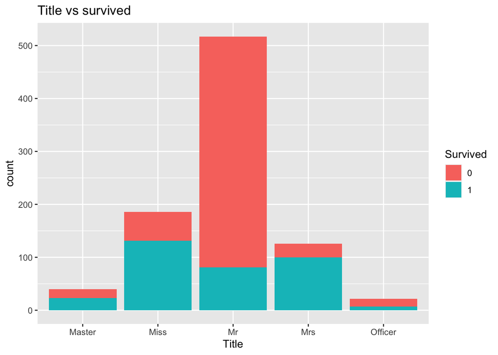

```r
ds_titanic_train <- ds_titanic[ which(ds_titanic$file_origin=='train'), ]
ds_titanic_test <- ds_titanic[ which(ds_titanic$file_origin=='test'), ]

ggplot(ds_titanic_train, aes(x=factor(Title), fill=factor(Survived)))+
  geom_bar()+
  xlab("Title")+
  scale_fill_discrete(name = "Survived") +
  ggtitle("Title vs survived")
```

## 4.2 Mida de la família (FamilySize)

A partir de les variables SibSp i Parch podrem derivar quina era la mida de la família de cada passatger. És a dir, si viatjaven sols o acompanyats.

```r
# Creem la variables
ds_titanic$FamilySize<-ds_titanic$SibSp+ds_titanic$Parch+1
```

### 4.2.1 Survival en funció de FamilySize

Visualitzem la taxa de supervivència en funció de la mida de la família

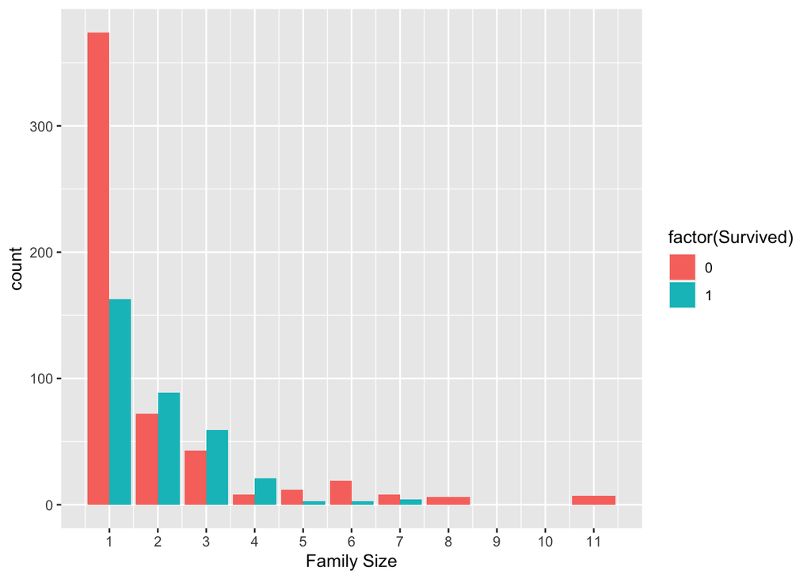

```r
ds_titanic_train <- ds_titanic[ which(ds_titanic$file_origin=='train'), ]
ds_titanic_test <- ds_titanic[ which(ds_titanic$file_origin=='test'), ]

ggplot(ds_titanic_train, aes(x = FamilySize, fill = factor(Survived))) +
  geom_bar(stat='count', position='dodge') +
  scale_x_continuous(breaks=c(1:12)) +
  labs(x = 'Family Size')
```

S’observa com tant els passatgers que viatgen sols com aquelles famílies amb de mida superior a 4 tenen menys possibilitats de sobreviure que la resta de passatgers amb una família d’entre 2 i 3 membres.

# 5 Valors extrems o outliers

## 5.1 Age

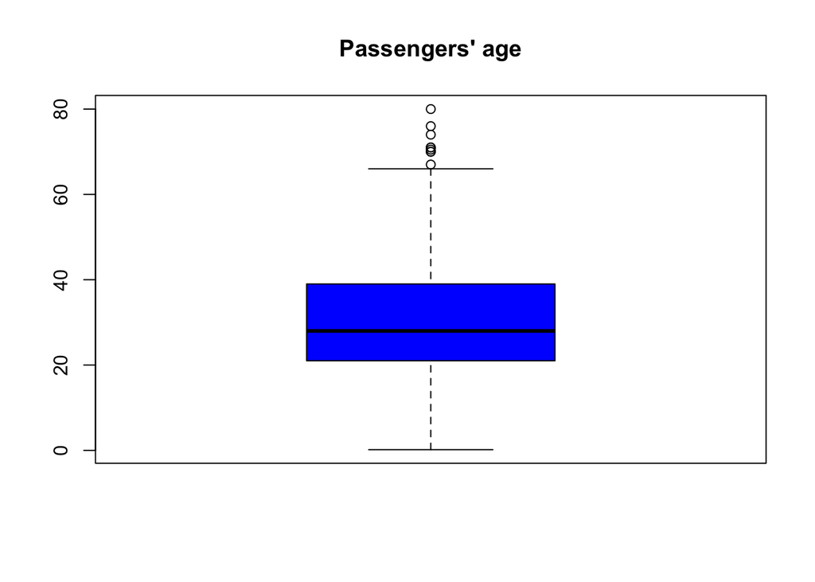

```r
boxplot(ds_titanic$Age, col="blue", border = "black", main = "Passengers' age")
```

Identifiquem els valors numèrics de les mostres que presenten aquests valors extrems

```r
age_outliers <- boxplot.stats(ds_titanic$Age)$out
# Mostrem les edats extremes, màximes i mínimes
sprintf("Maximum age %g", max(age_outliers))
```

```
## [1] "Maximum age 80"
```

```r
sprintf("Minimum age %g", min(age_outliers))
```

```
## [1] "Minimum age 67"
```

Aquests valors extrems són raonables i per tant els acceptarem com a vàlids.

## 5.2 Fare

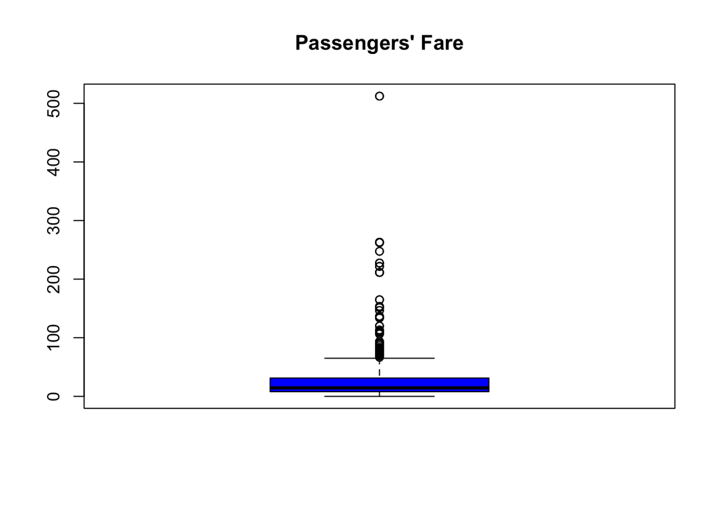

```r
boxplot(ds_titanic$Fare, col="blue", border = "black", main = "Passengers' Fare")
```

```r
fare_outliers <- boxplot.stats(ds_titanic$Fare)$out
# Mostrem dels valors exrems, els màxims i mínims
sprintf("Maximum Fare %g", max(fare_outliers))
```

```
## [1] "Maximum Fare 512.329"
```

```r
sprintf("Minimum Fare %g", min(fare_outliers))
```

```
## [1] "Minimum Fare 66.6"
```

## 5.3 SibSp

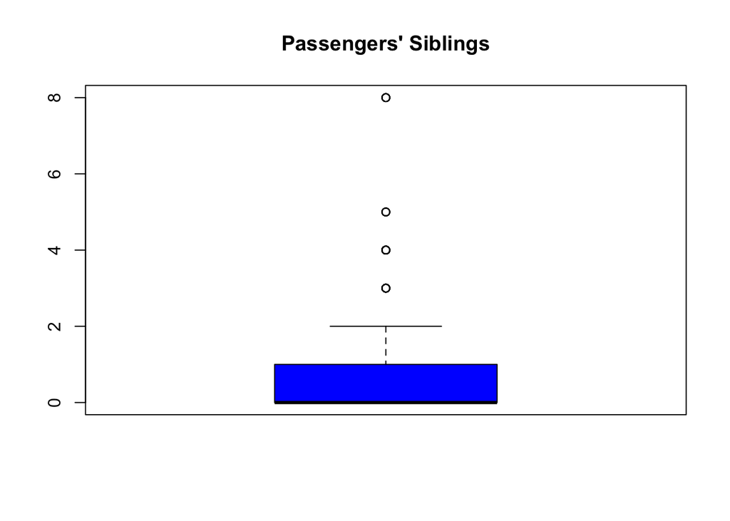

```r
boxplot(ds_titanic$SibSp, col="blue", border = "black", main = "Passengers' Siblings")
```

```r
sibsp_outliers <- boxplot.stats(ds_titanic$SibSp)$out
# Mostrem dels valors exrems, els màxims i mínims
sprintf("Maximum Siblings %g", max(sibsp_outliers))
```

```
## [1] "Maximum Siblings 8"
```

```r
sprintf("Minimum Siblings %g", min(sibsp_outliers))
```

```
## [1] "Minimum Siblings 3"
```

## 5.4 Parch

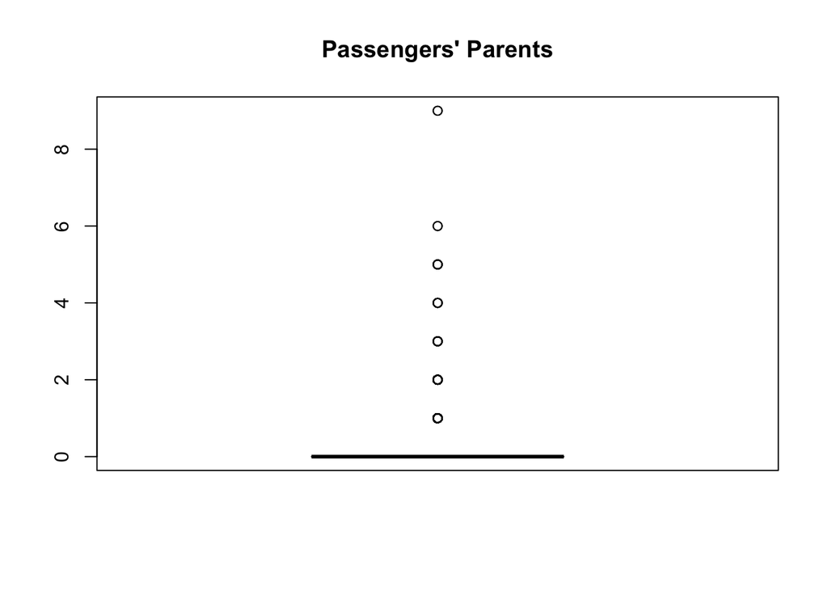

```r
boxplot(ds_titanic$Parch, col="blue", border = "black", main = "Passengers' Parents")
```

```r
parch_outliers <- boxplot.stats(ds_titanic$Parch)$out
# Mostrem dels valors exrems, els màxims i mínims
sprintf("Maximum Relatives %g", max(parch_outliers))
```

```
## [1] "Maximum Relatives 9"
```

```r
sprintf("Minimum Relatives %g", min(parch_outliers))
```

```
## [1] "Minimum Relatives 1"
```

# 6 Tractament de valors perduts

Tal i com s’ha comentat anteriorment, hi ha valors perduts en les variables Survived, Age, Cabin, Embarked i Fare. Primer, mirem quants valors en percentatge del total són NA o en blanc.

```r
# Susbtituim els valors blancs per NA
ds_titanic$Cabin[ds_titanic$Cabin == ''] <- NA
ds_titanic$Embarked[ds_titanic$Embarked == ''] <- NA
# Mirem els % de valors NA
colMeans(is.na(ds_titanic))*100
```

```
## PassengerId    Survived      Pclass        Name         Sex         Age
##  0.00000000 31.93277311  0.00000000  0.00000000  0.00000000 20.09167303
##       SibSp       Parch      Ticket        Fare       Cabin    Embarked
##  0.00000000  0.00000000  0.00000000  0.07639419 77.46371276  0.15278839
## file_origin       Title  FamilySize
##  0.00000000  0.00000000  0.00000000
```

Analitzarem cada variable per separat i en tractarem els seus valors NA.

## 6.1 Cabin

```r
# Mirem les primeres observacions
head(ds_titanic$Cabin,30)
```

```
##  [1] NA            "C85"         NA            "C123"        NA
##  [6] NA            "E46"         NA            NA            NA
## [11] "G6"          "C103"        NA            NA            NA
## [16] NA            NA            NA            NA            NA
## [21] NA            "D56"         NA            "A6"          NA
## [26] NA            NA            "C23 C25 C27" NA            NA
```

Tenim un gran nombre de NA per la variable Cabine, amb un 77.5% d’observacions no contestades. Per aquest motiu no la inclourem en el model.

## 6.2 Embarked

Com que només ens falten dos valors, els substituirem pel valor més freqüent

```r
mode_embarked <- names(table(ds_titanic$Embarked))[table(ds_titanic$Embarked) == max(table(ds_titanic$Embarked))]
ds_titanic$Embarked[is.na(ds_titanic$Embarked)] <- mode_embarked
```

## 6.3 Fare

```r
mean_fare <- mean(ds_titanic$Fare, na.rm=TRUE)
ds_titanic$Fare[is.na(ds_titanic$Fare)] <- mean_fare
```

## 6.4 Age

Tornem a mirar quants valors NA hi ha.

```r
sum(is.na(ds_titanic$Age))
```

```
## [1] 263
```

Es manca un valor per a 263 passatgers, que representa un 20% de les observacions.

Per tal d’imputar l’edat, s’utilitzarà el paquet de R “Mice”. Aquest ens permetrà fer una estimació molt acurada de l’edat dels passatgers que falten, a partir de les altres variables.

```r
# Factorització de variables
ds_titanic$Pclass<-factor(ds_titanic$Pclass)
ds_titanic$Sex<-factor(ds_titanic$Sex)
ds_titanic$Embarked<-factor(ds_titanic$Embarked)
ds_titanic$Title<-factor(ds_titanic$Title)
ds_titanic$FamilySize<-factor(ds_titanic$FamilySize)
ds_titanic$Survived<-factor(ds_titanic$Survived)

# Definició d'un random seed
set.seed(128)
mice_model<-mice(ds_titanic[,names(ds_titanic) %in% c('Pclass','Sex','Embarked','Title','Age','SibSp','Parch','Fare')],method='rf')
```

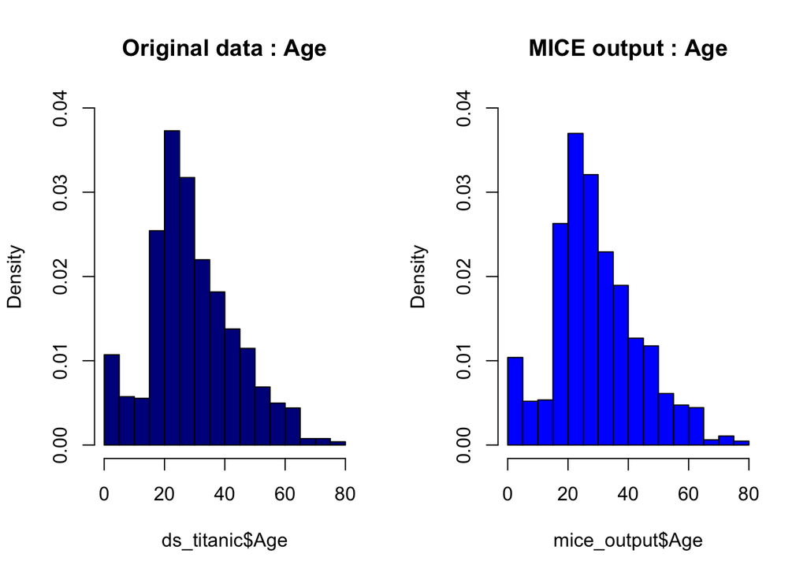

```r
mice_output<-complete(mice_model)
par(mfrow=c(1,2))
hist(ds_titanic$Age, freq=F,main="Original data : Age", col="dark blue", ylim=c(0,0.04))
hist(mice_output$Age, freq=F,main="MICE output : Age", col="blue", ylim=c(0,0.04))
```

Es pot observar que la distribució de la variable Age en el data set original (amb els valors NA) és molt semblant a la distribució amb el paquet “Mice”. Per tant, podem concloure que l’estimació de l’edat basada en les altres variables és acurada. Conseqüentment, utilitzarem aquesta edat per reemplaçar els valors NA.

```r
ds_titanic$Age<-mice_output$Age

ds_titanic_train <- ds_titanic[ which(ds_titanic$file_origin=='train'), ]
ds_titanic_test <- ds_titanic[ which(ds_titanic$file_origin=='test'), ]
```

```r
# Tornem a mirar si hi ha valors buits
sum(is.na(ds_titanic_train$Age))
```

```
## [1] 0
```

Ja no tenim valors perduts en el ds_titanic_train, pel que tenim les dades netes.

# 7 Discretitzacions

Creiem convenient aplicar certa discretització tant a nivell de Age com de FamilySize per tal de reduir el nombre de possibilitats d’observacions dins de cada atribut.

## 7.1 Age

Discretitzem l’edat. D’aquesta manera, agrupem els passatgers en cinc grups d’edat

```r
summary(ds_titanic$Age)
```

```
##    Min. 1st Qu.  Median    Mean 3rd Qu.    Max.
##    0.17   21.00   28.00   29.88   38.00   80.00
```

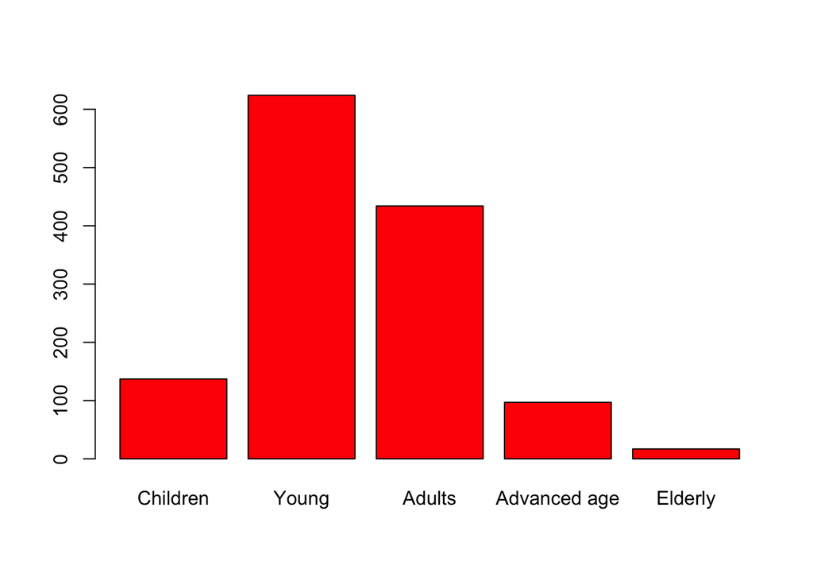

```r
ds_titanic$Age.factor <- cut(ds_titanic$Age, breaks = c(0,15,30,50,64,100), labels=c('Children', 'Young','Adults','Advanced age','Elderly'))

plot(ds_titanic$Age.factor, col="red")
```

Observem que la majoria de passatgers són joves d’entre 15 i 29 anys.

## 7.2 FamilySize

Discretitzem la mida de la família.

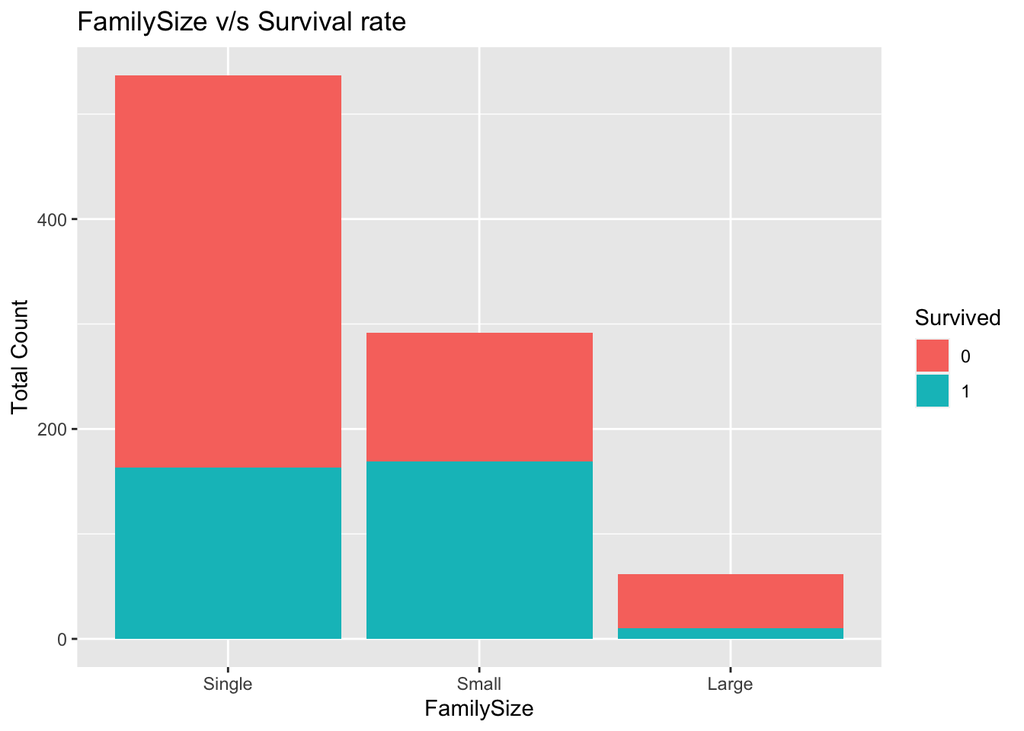

```r
ds_titanic$FamilySize <- as.numeric(ds_titanic$FamilySize)
ds_titanic$FamilySize.factor <- cut(ds_titanic$FamilySize, breaks = c(0,1,4,90), labels=c('Single', 'Small','Large'))

ds_titanic_train <- ds_titanic[ which(ds_titanic$file_origin=='train'), ]
ds_titanic_test <- ds_titanic[ which(ds_titanic$file_origin=='test'), ]

# Representem gràficament el resultat
ggplot(data = ds_titanic_train, aes(x=FamilySize.factor, fill=Survived)) +
        geom_bar() +
        ggtitle("FamilySize v/s Survival rate") +
        xlab("FamilySize") +
        ylab("Total Count") +
        labs(fill = "Survived")
```

```r
prop.table(table(ds_titanic_train$FamilySize.factor, ds_titanic_train$Survived), margin = 1) %>% round(digits = 2)
```

```
##
##             0    1
##   Single 0.70 0.30
##   Small  0.42 0.58
##   Large  0.84 0.16
```

```r
ds_titanic$FamilySize <- as.factor(ds_titanic$FamilySize)
```

```r
# Guardem el fitxer train net creat
write.csv(ds_titanic_train,file="train_net.csv",row.names = T)

# Guardem el fitxer test net creat
write.csv(ds_titanic_test,file="test_net.csv",row.names = T)
```

# 8 Normalitat i homoscedasticitat

## 8.1 Normalitat

### 8.1.1 Survival

Distribució de la variable a predir, la supervivència

```r
ds_titanic_train <- ds_titanic[ which(ds_titanic$file_origin=='train'), ]
ds_titanic_test <- ds_titanic[ which(ds_titanic$file_origin=='test'), ]

table(ds_titanic_train$Survived)
```

```
##
##   0   1
## 549 342
```

```r
prop.table(table(ds_titanic_train$Survived)) %>% '*' (100) %>% round(digits = 2)
```

```
##
##     0     1
## 61.62 38.38
```

Del total de 891 observacions, la majoria no van sobreviure al naufragi. De fet, només ho van fer el 38.38% dels passatgers i tripulació.

### 8.1.2 Age

Mirem la distribució d’Age.

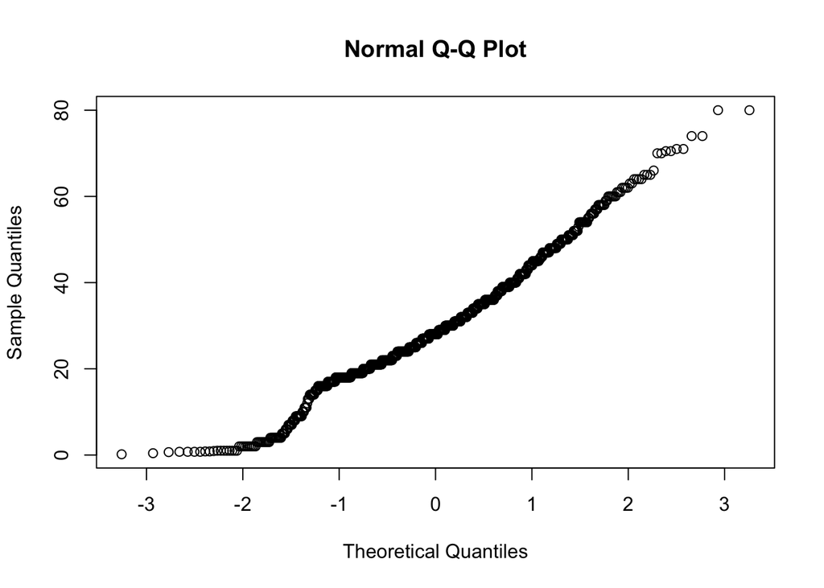

```r
# Gràficament, en un qqplot
qqnorm(ds_titanic_train$Age)
```

Segons el gràfic, pot semblar que s’apropa a la normalitat en el centre, però no en els extrems.

Comprovem la normalitat a través d’un Shapiro test, amb un nivell de significació del 5%, on la hipòtesis nul·la assumeix normalitat

```r
shapiro.test(ds_titanic_train$Age)
```

```
##
##  Shapiro-Wilk normality test
##
## data:  ds_titanic_train$Age
## W = 0.97945, p-value = 7.002e-10
```

Tot i que pel teorema central del límit podríem considerar que segueix una distribució normal, el resultat obtingut pel Shapiro Test indica que la hipòtesis nul·la és rebutjada, pel que podem afirmar que la variable Age no segueix una distribució normal.

Observem la distribució en funció de la supervivència

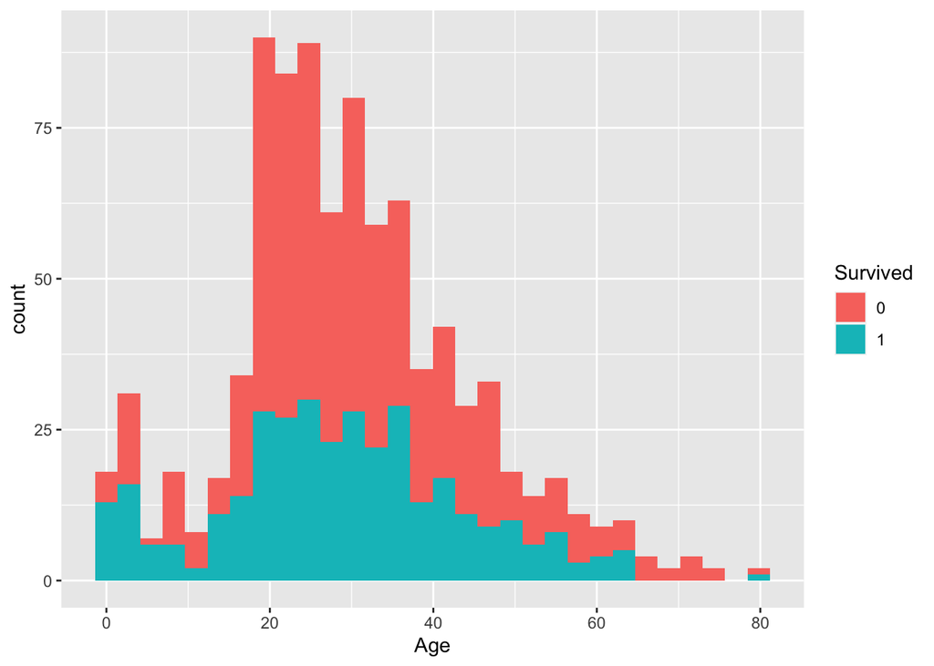

```r
ggplot(data = ds_titanic_train) + aes (x = Age, fill = Survived) + geom_histogram()
```

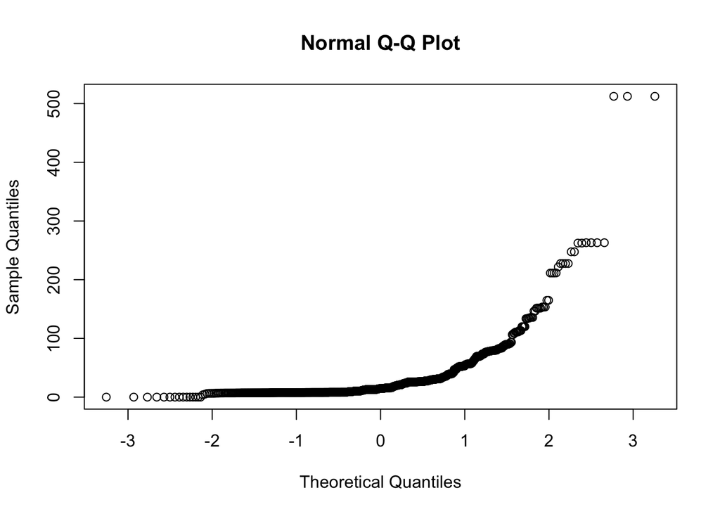

```r
# Gràficament, en un qqplot
qqnorm(ds_titanic_train$Fare)
```

Clarament veiem que no segueix una distribució normal, pel que no és necessari comprovar-ho amb un test numèric.

### 8.1.3 SibSp

Mirem la distribució de SibSp

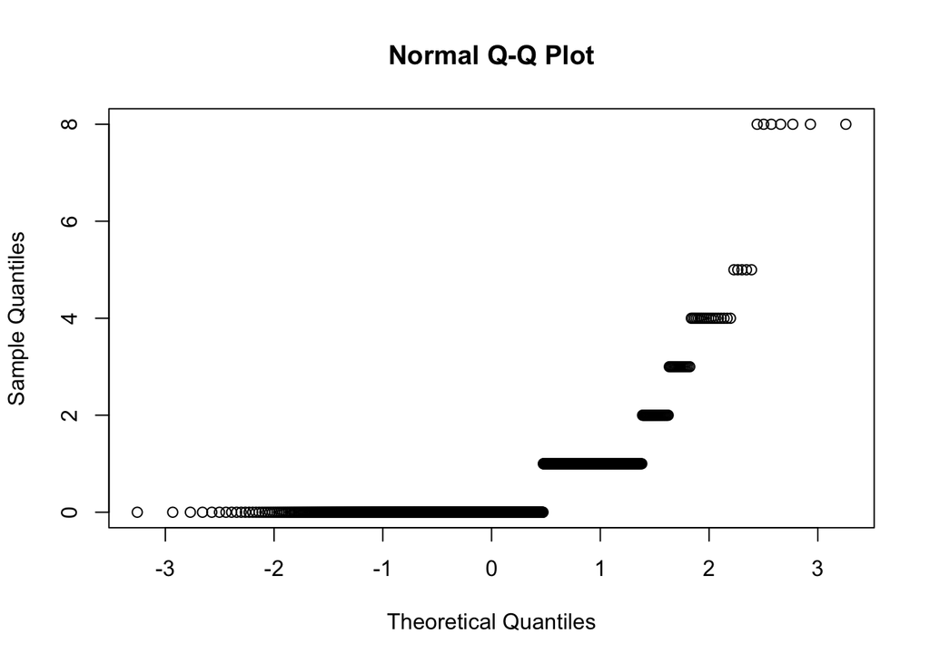

```r
# Gràficament, en un qqplot
qqnorm(ds_titanic_train$SibSp)
```

Igual que per a la variable Fare, també veiem a cop d’ull que no segueix una distribució normal.

### 8.1.4 Parch

Mirem la distribució Parch

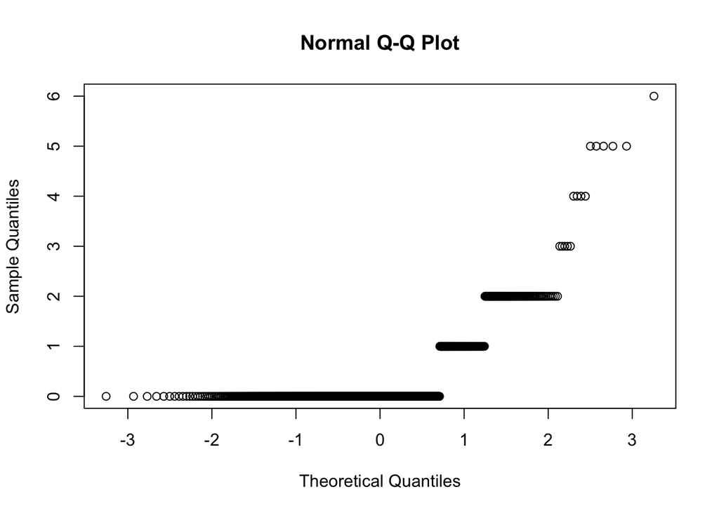

```r
# Gràficament, en un qqplot
qqnorm(ds_titanic_train$Parch)
```

Per a la última variable numèrica, veiem que tampoc segueix una distribució normal.

## 8.2 Homoscedasticitat

Igual que per la normalitat, la comprovació de la homoscedasticitat només es pot fer en variables numèriques, pel que ho comprovem per a les variables Age, Fare, SibSp i Parch. Comprovem si la variança d’aquestes és significativament diferent a la de Survived, amb un nivell de significació del 5%.

### 8.2.1 Age

Fem un test de Variància (F-TEST) per analitzar si la variància de l’edat entre les mostres que sobreviuen i les que no poden considerar-se iguals.

```r
var.test(x = ds_titanic_train[ds_titanic_train$Survived == "0",'Age'],
         y = ds_titanic_train[ds_titanic_train$Survived == "1",'Age']
         )
```

```
##
##  F test to compare two variances
##
## data:  ds_titanic_train[ds_titanic_train$Survived == "0", "Age"] and ds_titanic_train[ds_titanic_train$Survived == "1", "Age"]
## F = 0.89666, num df = 548, denom df = 341, p-value = 0.2586
## alternative hypothesis: true ratio of variances is not equal to 1
## 95 percent confidence interval:
##  0.7388307 1.0835216
## sample estimates:
## ratio of variances
##          0.8966649
```

### 8.2.2 Fare

```r
var.test(x = ds_titanic_train[ds_titanic_train$Survived == "0",'Fare'],
         y = ds_titanic_train[ds_titanic_train$Survived == "1",'Fare']
         )
```

```
##
##  F test to compare two variances
##
## data:  ds_titanic_train[ds_titanic_train$Survived == "0", "Fare"] and ds_titanic_train[ds_titanic_train$Survived == "1", "Fare"]
## F = 0.22214, num df = 548, denom df = 341, p-value < 2.2e-16
## alternative hypothesis: true ratio of variances is not equal to 1
## 95 percent confidence interval:
##  0.1830368 0.2684300
## sample estimates:
## ratio of variances
##          0.2221384
```

Rebutjem la hipòtesis nul·la, per tant hi ha diferències significatives per les variances entre les variables.

### 8.2.3 SibSp

```r
var.test(x = ds_titanic_train[ds_titanic_train$Survived == "0",'SibSp'],
         y = ds_titanic_train[ds_titanic_train$Survived == "1",'SibSp']
         )
```

```
##
##  F test to compare two variances
##
## data:  ds_titanic_train[ds_titanic_train$Survived == "0", "SibSp"] and ds_titanic_train[ds_titanic_train$Survived == "1", "SibSp"]
## F = 3.3052, num df = 548, denom df = 341, p-value < 2.2e-16
## alternative hypothesis: true ratio of variances is not equal to 1
## 95 percent confidence interval:
##  2.723366 3.993914
## sample estimates:
## ratio of variances
##           3.305151
```

També rebutjem la hipòtesis nul·la per la variable SibSp, pel que les variances són diferents.

### 8.2.4 Parch

```r
var.test(x = ds_titanic_train[ds_titanic_train$Survived == "0",'Parch'],
         y = ds_titanic_train[ds_titanic_train$Survived == "1",'Parch']
         )
```

```
##
##  F test to compare two variances
##
## data:  ds_titanic_train[ds_titanic_train$Survived == "0", "Parch"] and ds_titanic_train[ds_titanic_train$Survived == "1", "Parch"]
## F = 1.1378, num df = 548, denom df = 341, p-value = 0.1908
## alternative hypothesis: true ratio of variances is not equal to 1
## 95 percent confidence interval:
##  0.9375169 1.3749020
## sample estimates:
## ratio of variances
##           1.137796
```

Acceptem la hipòtesis nul·la, pel que les variances són similars.

## 8.3 Matriu de Correlacions

Amb una matriu de correlacions volem observar quines variables tenen una correlació significativa entre elles

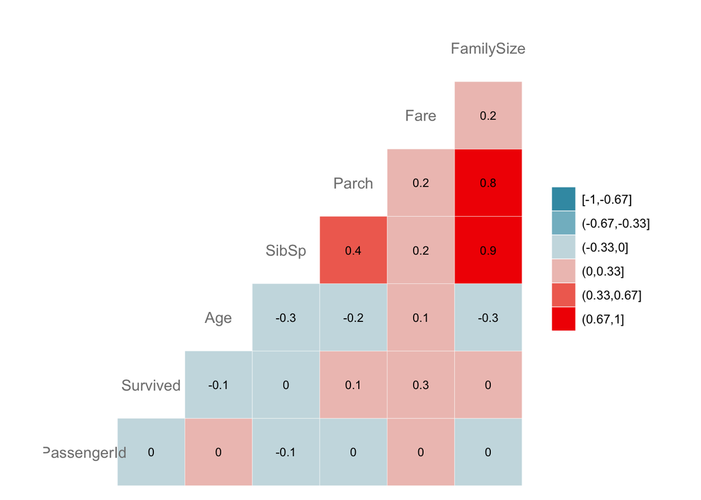

```r
# Conversió dels valors a numèrics
data_num <- ds_titanic_train

data_num$Survived <- as.numeric(data_num$Survived)
data_num$FamilySize <- as.numeric(data_num$FamilySize)

drop <- c("Title")
data_num <- data_num[, !(names(data_num) %in% drop)]

ggcorr (data_num,
       nbreaks = 6,
       label = TRUE,
       label_size = 3,
       color = "grey50")
```

En aquesta matriu de correlacions s’observa, de forma evident, que la correlació entre FamilySize amb Parch i SibSp és molt forta. No és sorprenent, ja que FamilySize s’ha derivat d’aquestes dues.

A més a més, es veu també que hi ha una correlació inversa entre Age i Survived. És a dir, a menor edat, major supervivència.

## 8.4 Relacions de dependència

```r
# Apliquem un "relevel", així establint el pendent com a 0 (no supervivent)
ds_titanic_train$Survived <- relevel(ds_titanic_train$Survived, ref = "0")
```

### 8.4.1 Sex

```r
chisq.test(table(ds_titanic_train$Sex, ds_titanic_train$Survived))
```

```
##
##  Pearson's Chi-squared test with Yates' continuity correction
##
## data:  table(ds_titanic_train$Sex, ds_titanic_train$Survived)
## X-squared = 260.72, df = 1, p-value < 2.2e-16
```

Ja que el p-value és més petit que 0.05, rebutjem la hipòtesis nul·la. Per tant, podem afirmar que les variables Sex i Survived són dependents.

### 8.4.2 Age

```r
chisq.test(table(ds_titanic_train$Age, ds_titanic_train$Survived))
```

```
##
##  Pearson's Chi-squared test
##
## data:  table(ds_titanic_train$Age, ds_titanic_train$Survived)
## X-squared = 113.24, df = 90, p-value = 0.04936
```

Rebutjem la hipòtesis nul·la i, per tant, les variables Age i Survived tenen una dependència significativa.

### 8.4.3 PClass

```r
chisq.test(table(ds_titanic_train$Pclass, ds_titanic_train$Survived))
```

```
##
##  Pearson's Chi-squared test
##
## data:  table(ds_titanic_train$Pclass, ds_titanic_train$Survived)
## X-squared = 102.89, df = 2, p-value < 2.2e-16
```

Ja que el p-vlaue és inferior a 0.05, afirmem que les variables PClass i Survived tenen una associació significativa.

### 8.4.4 Embarked

```r
chisq.test(table(ds_titanic_train$Embarked, ds_titanic_train$Survived))
```

```
##
##  Pearson's Chi-squared test
##
## data:  table(ds_titanic_train$Embarked, ds_titanic_train$Survived)
## X-squared = 25.964, df = 2, p-value = 2.301e-06
```

Altra vegada, podem concloure que les variables Embarked i Survived són dependents, ja que el p-value és inferior al nivell de significació

### 8.4.5 FamilySize

```r
chisq.test(table(ds_titanic_train$FamilySize, ds_titanic_train$Survived))
```

```
##
##  Pearson's Chi-squared test
##
## data:  table(ds_titanic_train$FamilySize, ds_titanic_train$Survived)
## X-squared = 80.672, df = 8, p-value = 3.58e-14
```

Finalment, veiem que les variables FamilySize i Survived també són dependents una de l’altra.

### 8.4.6 Age

Per poder aplicar proves de contrast d’hipòtesis paramètriques (com t Student) cal que les variables:

- Tinguin una distribució normal
- Les seves variàncies han de mantenir-se contants en tot el rang observat d’alguna altra variable

Aquestes condicions no es compleixen per la variable Age i com a solució emprarem una prova no paramètrica. En aquest cas, com que tenim mostres independents, emprarem el test U de Mann-Whitney.

```r
data_alive = ds_titanic_train[ds_titanic_train$Survived =="1",]
data_notalive = ds_titanic_train[ds_titanic_train$Survived =="0",]

resultat_contrast <- wilcox.test(x=data_alive$Age, y=data_notalive$Age, alternative = "less", mu=20, paired = FALSE, conf.int=0.95)
resultat_contrast
```

```
##
##  Wilcoxon rank sum test with continuity correction
##
## data:  data_alive$Age and data_notalive$Age
## W = 26430, p-value < 2.2e-16
## alternative hypothesis: true location shift is less than 20
## 95 percent confidence interval:
##          -Inf 2.242463e-05
## sample estimates:
## difference in location
##              -1.000002
```

# 9 Train i Test

Per tal de crear un model, entrenar-lo i testejar la seva bondat de predicció, primer separarem les dades en test i train. Les dades train s’empraran per a entrenar el model, mentre que les test per validar-lo.

```r
# Ens quedem amb les variables que volem pel model
# Age,Survived,Pclass,Sex,Fare,Familysize,Embarked and Title
titanic_sub <- ds_titanic_train[,c(2,3,5,6,10,12,14,15,16,17)]

# Determinem un random seed
set.seed(123)
split = sample.split(titanic_sub$Survived, SplitRatio = 0.75)
training_set = subset(titanic_sub, split == TRUE)
test_set = subset(titanic_sub, split == FALSE)

# Observem el resultat
str(training_set)
```

```
## 'data.frame':    668 obs. of  10 variables:
##  $ Survived         : Factor w/ 2 levels "0","1": 1 2 2 2 1 2 2 2 1 1 ...
##  $ Pclass           : Factor w/ 3 levels "1","2","3": 3 1 3 1 3 3 3 1 3 3 ...
##  $ Sex              : Factor w/ 2 levels "female","male": 2 1 1 1 2 1 1 1 2 2 ...
##  $ Age              : num  22 38 26 35 31 27 4 58 20 39 ...
##  $ Fare             : num  7.25 71.28 7.92 53.1 8.46 ...
##  $ Embarked         : Factor w/ 3 levels "C","Q","S": 3 1 3 3 2 3 3 3 3 3 ...
##  $ Title            : Factor w/ 5 levels "Master","Miss",..: 3 4 2 4 3 4 2 2 3 3 ...
##  $ FamilySize       : Factor w/ 9 levels "1","2","3","4",..: 2 2 1 2 1 3 3 1 1 7 ...
##  $ Age.factor       : Factor w/ 5 levels "Children","Young",..: 2 3 2 3 3 2 1 4 2 3 ...
##  $ FamilySize.factor: Factor w/ 3 levels "Single","Small",..: 2 2 1 2 1 2 2 1 1 3 ...
```

El nou dataset conté 10 variables, on 668 observacions s’utilitzaran per entrenar el model.

# 10 Models

## 10.1 Models de regressió

Creem diversos models de regressió per veure quines variables ajuden a prediure de manera més precisa si el passatger sobreviuria o no al naufragi. Ho provarem amb Sex i Embarked.

### 10.1.1 Survived & Sex

Es tracta de trobar en quin percentatge es modifica la probabilitat de supervivència en funció del gendre. Aquesta variació en probabilitat pot ser representada a partir d’una regressió logística obtenida com a 1-odds %.

Dins la regressió, la intersecció (“Intercept”) recull els factors més favorables. Per altre costat, els odds (en %) ens indicaran la variació en probabilitat de supervivència.

```r
model.glm <- glm(Survived ~ Sex, data = training_set, family = binomial )
summary (model.glm)
```

```
##
## Call:
## glm(formula = Survived ~ Sex, family = binomial, data = training_set)
##
## Deviance Residuals:
##     Min       1Q   Median       3Q      Max
## -1.6651  -0.6253  -0.6253   0.7585   1.8592
##
## Coefficients:
##             Estimate Std. Error z value Pr(>|z|)
## (Intercept)   1.0986     0.1491    7.37 1.71e-13 ***
## Sexmale      -2.6315     0.1955  -13.46  < 2e-16 ***
## ---
## Signif. codes:  0 '***' 0.001 '**' 0.01 '*' 0.05 '.' 0.1 ' ' 1
##
## (Dispersion parameter for binomial family taken to be 1)
##
##     Null deviance: 889.27  on 667  degrees of freedom
## Residual deviance: 670.26  on 666  degrees of freedom
## AIC: 674.26
##
## Number of Fisher Scoring iterations: 4
```

```r
odds <- or_glm(data = training_set, model = model.glm)
odds
```

```
##   predictor oddsratio ci_low (2.5) ci_high (97.5)          increment
## 1   Sexmale     0.072        0.049          0.105 Indicator variable
```

```r
p_odds <- odds[1,1:2]
p_odds["%"] <- (1-p_odds[2])*100
p_odds
```

```
##   predictor oddsratio    %
## 1   Sexmale     0.072 92.8
```

Tal i com s’observa, la probabilitat de que els homes sobrevisquin decreix respecte les dones en un 92,8%.

### 10.1.2 Survived & Embarked

```r
model.glm <- glm(Survived ~ Embarked, data = training_set, family = binomial )
summary (model.glm)
```

```
##
## Call:
## glm(formula = Survived ~ Embarked, family = binomial, data = training_set)
##
## Deviance Residuals:
##     Min       1Q   Median       3Q      Max
## -1.2802  -0.9105  -0.9105   1.4702   1.4702
##
## Coefficients:
##             Estimate Std. Error z value Pr(>|z|)
## (Intercept)   0.2384     0.1854   1.286   0.1985
## EmbarkedQ    -0.6279     0.3380  -1.857   0.0632 .
## EmbarkedS    -0.9046     0.2082  -4.345 1.39e-05 ***
## ---
## Signif. codes:  0 '***' 0.001 '**' 0.01 '*' 0.05 '.' 0.1 ' ' 1
##
## (Dispersion parameter for binomial family taken to be 1)
##
##     Null deviance: 889.27  on 667  degrees of freedom
## Residual deviance: 870.12  on 665  degrees of freedom
## AIC: 876.12
##
## Number of Fisher Scoring iterations: 4
```

```r
odds <- or_glm(data = training_set, model = model.glm)
odds
```

```
##   predictor oddsratio ci_low (2.5) ci_high (97.5)          increment
## 1 EmbarkedQ     0.534        0.272          1.030 Indicator variable
## 2 EmbarkedS     0.405        0.268          0.608 Indicator variable
```

```r
p_odds <- odds[1,1:2]
p_odds["%"] <- (1-p_odds[2])*100
p_odds
```

```
##   predictor oddsratio    %
## 1 EmbarkedQ     0.534 46.6
```

Tal i com s’observa, la probabilitat que els passatgers que van embarcar al port Q sobrevisquin decreix respecte el port C en un 46.6%.

## 10.2 Regressió logística multivariable

Després de crear dos models de regressió univariables, procedim a crear un model multivariable, així tenint en compte tots els atributs.

```r
model_mult1 <- glm( Survived ~ Age + Pclass + Sex + Embarked + FamilySize, data = training_set, family = binomial)
summary(model_mult1)
```

```
##
## Call:
## glm(formula = Survived ~ Age + Pclass + Sex + Embarked + FamilySize,
##     family = binomial, data = training_set)
##
## Deviance Residuals:
##     Min       1Q   Median       3Q      Max
## -2.8741  -0.5743  -0.3811   0.5466   2.5994
##
## Coefficients:
##               Estimate Std. Error z value Pr(>|z|)
## (Intercept)   4.132122   0.536988   7.695 1.42e-14 ***
## Age          -0.035737   0.009277  -3.852 0.000117 ***
## Pclass2      -1.037481   0.327963  -3.163 0.001559 **
## Pclass3      -2.159995   0.311184  -6.941 3.89e-12 ***
## Sexmale      -2.926782   0.244842 -11.954  < 2e-16 ***
## EmbarkedQ    -0.106787   0.476860  -0.224 0.822806
## EmbarkedS    -0.452285   0.287558  -1.573 0.115754
## FamilySize2  -0.257505   0.294294  -0.875 0.381578
## FamilySize3   0.540466   0.333020   1.623 0.104606
## FamilySize4   0.505674   0.605973   0.834 0.404009
## FamilySize5  -2.337015   0.856940  -2.727 0.006388 **
## FamilySize6  -1.910107   0.836816  -2.283 0.022455 *
## FamilySize7  -1.829604   0.905681  -2.020 0.043369 *
## FamilySize8 -15.952346 852.217947  -0.019 0.985066
## FamilySize9 -16.707423 789.572463  -0.021 0.983118
## ---
## Signif. codes:  0 '***' 0.001 '**' 0.01 '*' 0.05 '.' 0.1 ' ' 1
##
## (Dispersion parameter for binomial family taken to be 1)
##
##     Null deviance: 889.27  on 667  degrees of freedom
## Residual deviance: 553.57  on 653  degrees of freedom
## AIC: 583.57
##
## Number of Fisher Scoring iterations: 15
```

Aquest model, el qual té en compte totes les variables, té un AIC de 583.57, pel que indica que la precisió del model és baixa. Voldrem comprovar si aquesta es pot millorar. Per tal de fer-ho, mirem quines variables no són signficatives. Veiem que Embarked no ho és en cap dels tres ports.

Per tant, tornem a realitzar el model però sense la variable Embarked.

```r
model_mult2 <- glm( Survived ~ Age + Pclass + Sex + FamilySize, data = training_set, family = binomial)
summary(model_mult2)
```

```
##
## Call:
## glm(formula = Survived ~ Age + Pclass + Sex + FamilySize, family = binomial,
##     data = training_set)
##
## Deviance Residuals:
##     Min       1Q   Median       3Q      Max
## -2.9503  -0.5696  -0.3935   0.5668   2.6049
##
## Coefficients:
##               Estimate Std. Error z value Pr(>|z|)
## (Intercept)   3.917381   0.504804   7.760 8.48e-15 ***
## Age          -0.036927   0.009249  -3.993 6.53e-05 ***
## Pclass2      -1.185784   0.315919  -3.753 0.000174 ***
## Pclass3      -2.227388   0.301089  -7.398 1.38e-13 ***
## Sexmale      -2.953832   0.241731 -12.219  < 2e-16 ***
## FamilySize2  -0.245676   0.291507  -0.843 0.399353
## FamilySize3   0.560684   0.330955   1.694 0.090239 .
## FamilySize4   0.495593   0.601026   0.825 0.409611
## FamilySize5  -2.382328   0.828140  -2.877 0.004018 **
## FamilySize6  -2.036635   0.844213  -2.412 0.015845 *
## FamilySize7  -1.983993   0.899596  -2.205 0.027424 *
## FamilySize8 -16.090139 850.901116  -0.019 0.984913
## FamilySize9 -16.862162 786.335428  -0.021 0.982891
## ---
## Signif. codes:  0 '***' 0.001 '**' 0.01 '*' 0.05 '.' 0.1 ' ' 1
##
## (Dispersion parameter for binomial family taken to be 1)
##
##     Null deviance: 889.27  on 667  degrees of freedom
## Residual deviance: 556.44  on 655  degrees of freedom
## AIC: 582.44
##
## Number of Fisher Scoring iterations: 15
```

```r
model_mult3 <- glm( Survived ~ Age + Pclass + Sex , data = training_set, family = binomial)
summary(model_mult3)
```

```
##
## Call:
## glm(formula = Survived ~ Age + Pclass + Sex, family = binomial,
##     data = training_set)
##
## Deviance Residuals:
##     Min       1Q   Median       3Q      Max
## -2.5705  -0.6606  -0.4070   0.6034   2.4821
##
## Coefficients:
##              Estimate Std. Error z value Pr(>|z|)
## (Intercept)  3.324747   0.416200   7.988 1.37e-15 ***
## Age         -0.029206   0.008144  -3.586 0.000336 ***
## Pclass2     -0.924989   0.297306  -3.111 0.001863 **
## Pclass3     -2.225656   0.285035  -7.808 5.79e-15 ***
## Sexmale     -2.672133   0.214859 -12.437  < 2e-16 ***
## ---
## Signif. codes:  0 '***' 0.001 '**' 0.01 '*' 0.05 '.' 0.1 ' ' 1
##
## (Dispersion parameter for binomial family taken to be 1)
##
##     Null deviance: 889.27  on 667  degrees of freedom
## Residual deviance: 595.78  on 663  degrees of freedom
## AIC: 605.78
##
## Number of Fisher Scoring iterations: 5
```

```r
model_mult4 <- glm(  Survived ~ Age.factor + Pclass + Sex , data = training_set, family = binomial)
summary(model_mult4)
```

```
##
## Call:
## glm(formula = Survived ~ Age.factor + Pclass + Sex, family = binomial,
##     data = training_set)
##
## Deviance Residuals:
##     Min       1Q   Median       3Q      Max
## -2.5795  -0.6813  -0.4249   0.6173   2.3188
##
## Coefficients:
##                        Estimate Std. Error z value Pr(>|z|)
## (Intercept)              3.2902     0.4230   7.779 7.33e-15 ***
## Age.factorYoung         -0.9082     0.3366  -2.699  0.00696 **
## Age.factorAdults        -1.1668     0.3584  -3.256  0.00113 **
## Age.factorAdvanced age  -1.2954     0.5285  -2.451  0.01424 *
## Age.factorElderly       -2.0989     1.1491  -1.827  0.06776 .
## Pclass2                 -0.8208     0.2923  -2.808  0.00499 **
## Pclass3                 -2.0961     0.2780  -7.541 4.65e-14 ***
## Sexmale                 -2.6451     0.2148 -12.314  < 2e-16 ***
## ---
## Signif. codes:  0 '***' 0.001 '**' 0.01 '*' 0.05 '.' 0.1 ' ' 1
##
## (Dispersion parameter for binomial family taken to be 1)
##
##     Null deviance: 889.27  on 667  degrees of freedom
## Residual deviance: 596.82  on 660  degrees of freedom
## AIC: 612.82
##
## Number of Fisher Scoring iterations: 5
```

### 10.2.1 Comprovació de la bondat del model

Un cop hem entrenat el model, anem a testejar la bondat del model amb el data set test.

```r
test_set$test.predict = predict.glm(model_mult4, test_set, type = 'response')
test_set$predict.logit = round(test_set$test.predict)
test_set$Survived2<-as.numeric(test_set$Survived)-1

# Matriu de confusió
confusionMatrix(as.factor(test_set$Survived2), as.factor(test_set$predict.logit))
```

```
## Confusion Matrix and Statistics
##
##           Reference
## Prediction   0   1
##          0 116  21
##          1  32  54
##
##                Accuracy : 0.7623
##                  95% CI : (0.7009, 0.8166)
##     No Information Rate : 0.6637
##     P-Value [Acc > NIR] : 0.0008825
##
##                   Kappa : 0.4862
##
##  Mcnemar's Test P-Value : 0.1695641
##
##             Sensitivity : 0.7838
##             Specificity : 0.7200
##          Pos Pred Value : 0.8467
##          Neg Pred Value : 0.6279
##              Prevalence : 0.6637
##          Detection Rate : 0.5202
##    Detection Prevalence : 0.6143
##       Balanced Accuracy : 0.7519
##
##        'Positive' Class : 0
##
```

Veiem que el model té un nivell de precisió del 76.2%. Per tant, en el 76,2 % dels casos, farà una predicció correcta.

## 10.3 Decision Tree Classification

Entrenem un altre tipus de model, un arbre de decisions. Així, podrem comprovar si aquest model supervisat és més precís que la regressió logística multivariable.

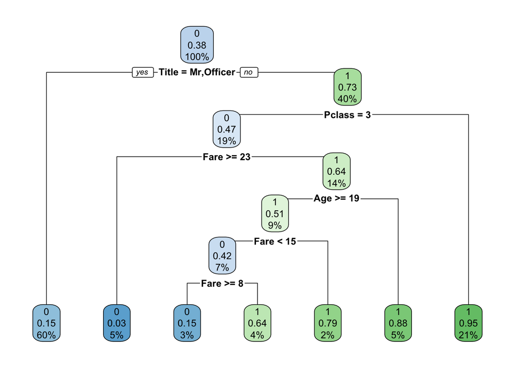

```r
# Entrenament del model
dec_tree_model <- rpart(Survived ~ Age + Sex + Pclass + FamilySize + Embarked + Title + Fare, data = training_set, method = "class")
# Representació gràfica
rpart.plot(dec_tree_model)
```

La interpretació d’aquest model es troba en el .pdf del GitHub.

### 10.3.1 Comprovació de la bondat del model

```r
# Matriu de confusió
pred_survived <- predict(dec_tree_model, newdata = test_set[-1], type="class")
table(test_set$Survived,pred_survived)
```

```
##    pred_survived
##       0   1
##   0 121  16
##   1  33  53
```

```r
# Avaluació de la precisió
mean(test_set$Survived==pred_survived)
```

```
## [1] 0.7802691
```

El model arbre de decisió obtingut té una precisió del 78.03%

## 10.4 Random forest Classification

Entrenem un altre model, el Random Forest, per veure quin dels tres models és més precís.

```r
set.seed(123)
rf_model <- randomForest(Survived~Age+Sex+Pclass+FamilySize+Embarked+Title+Fare,data = training_set)
print(rf_model)
```

```
##
## Call:
##  randomForest(formula = Survived ~ Age + Sex + Pclass + FamilySize +      Embarked + Title + Fare, data = training_set)
##                Type of random forest: classification
##                      Number of trees: 500
## No. of variables tried at each split: 2
##
##         OOB estimate of  error rate: 15.57%
## Confusion matrix:
##     0   1 class.error
## 0 378  34  0.08252427
## 1  70 186  0.27343750
```

En la matriu de confusió apareixen la quantitat d’encerts i errades obtingudes en la predicció de la supervivència.

### 10.4.1 Comprovació de la bondat del model

```r
rf_pred<-predict(rf_model,test_set)
mean(test_set$Survived==rf_pred)
```

```
## [1] 0.8026906
```

Amb aquest model, obtenim una precisió del 80.3%, la qual és la millor que hem obtingut fins ara. El resum mostra un estimació de l’error del 15.57%.

A continuació, comprovem quines són les variables més importants dins d’aquest model

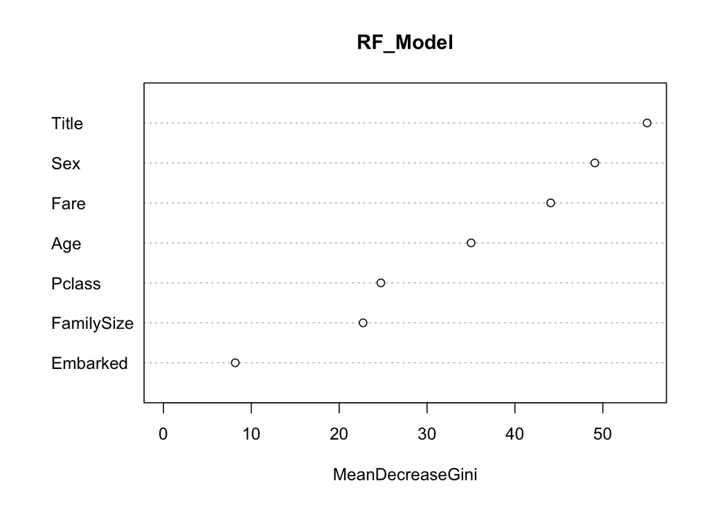

```r
varImpPlot(rf_model,main="RF_Model")
```

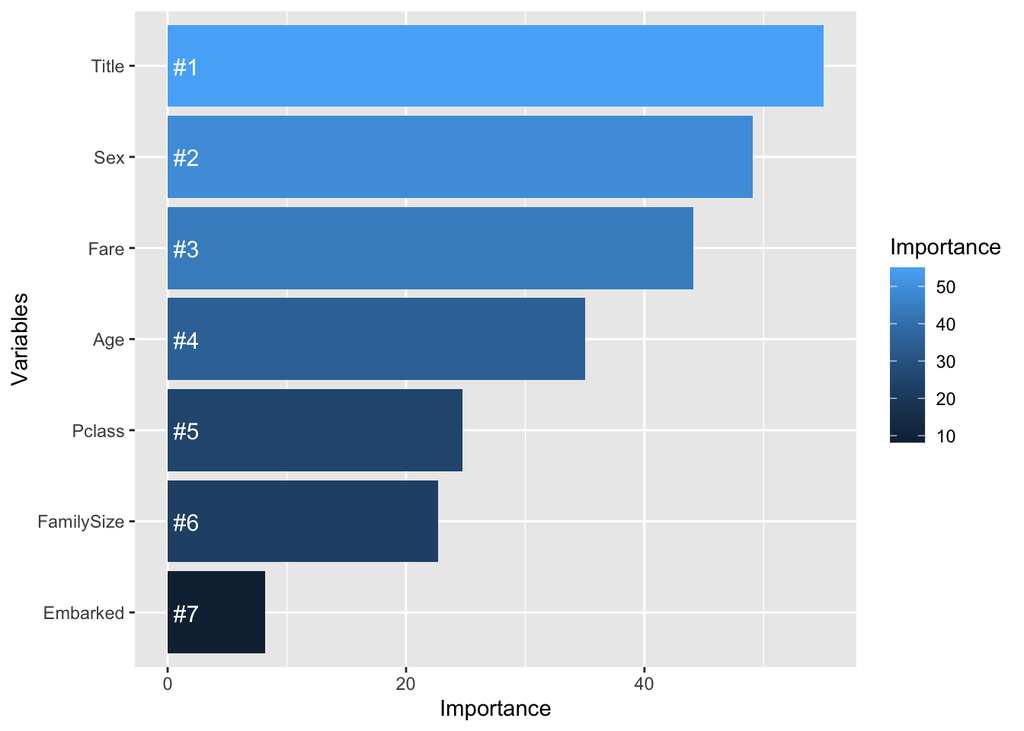

```r
importance    <- importance(rf_model)
varImportance <- data.frame(Variables = row.names(importance),
                            Importance = round(importance[ ,'MeanDecreaseGini'],2))

# Creem un ranking basat en la importància
rankImportance <- varImportance %>%
  mutate(Rank = paste0('#',dense_rank(desc(Importance))))

# Visualitzem la importància
ggplot(rankImportance, aes(x = reorder(Variables, Importance),
                           y = Importance, fill = Importance)) +
  geom_bar(stat='identity') +
  geom_text(aes(x = Variables, y = 0.5, label = Rank),
            hjust=0, vjust=0.55, size = 4, colour = 'white') +
  labs(x = 'Variables') +
  coord_flip()
```

A través del gràfic veiem que les variables Title, Sex i Fare són les més importants en la nostra predicció de supervivència dins d’aquest tercer model.

# 11 Prediccions

## 11.1 Predicció un passatger

En primer lloc, creem una predicció d’un sol passatger. Escollirem el passatger número 71 i utilitzarem el tercer model entrenat, ja que té el nivell de precisió més alt de tots.

```r
prediccio_base <- ds_titanic_test

passatger_individual <- prediccio_base[71,]

rf_kaggle <- predict(rf_model,passatger_individual)
passatger_individual$Survived <- rf_kaggle
head(passatger_individual)
```

```
##     PassengerId Survived Pclass                      Name    Sex Age SibSp
## 962         962        1      3 Mulvihill, Miss. Bertha E female  24     0
##     Parch Ticket Fare Cabin Embarked file_origin Title FamilySize Age.factor
## 962     0 382653 7.75  <NA>        Q        test  Miss          1      Young
##     FamilySize.factor
## 962            Single
```

Aplicant el model amb millor precisió, el Random Forest Classification, pel passatger 71 amb PassatgerId = 962, del qual en desconeixem la supervivència, ens prediu que sobreviurà.

## 11.2 Predicció Total

Finalment, realitzem una predicció global. És a dir, realitzem una predicció total sobre el fitxer entregat pel Kaggle.

```r
rf_kaggle<-predict(rf_model,ds_titanic_test)
ds_titanic_test$Survived<-rf_kaggle
head(ds_titanic_test)
```

```
##     PassengerId Survived Pclass                                         Name
## 892         892        0      3                             Kelly, Mr. James
## 893         893        0      3             Wilkes, Mrs. James (Ellen Needs)
## 894         894        0      2                    Myles, Mr. Thomas Francis
## 895         895        0      3                             Wirz, Mr. Albert
## 896         896        1      3 Hirvonen, Mrs. Alexander (Helga E Lindqvist)
## 897         897        0      3                   Svensson, Mr. Johan Cervin
##        Sex  Age SibSp Parch  Ticket    Fare Cabin Embarked file_origin Title
## 892   male 34.5     0     0  330911  7.8292  <NA>        Q        test    Mr
## 893 female 47.0     1     0  363272  7.0000  <NA>        S        test   Mrs
## 894   male 62.0     0     0  240276  9.6875  <NA>        Q        test    Mr
## 895   male 27.0     0     0  315154  8.6625  <NA>        S        test    Mr
## 896 female 22.0     1     1 3101298 12.2875  <NA>        S        test   Mrs
## 897   male 14.0     0     0    7538  9.2250  <NA>        S        test    Mr
##     FamilySize   Age.factor FamilySize.factor
## 892          1       Adults            Single
## 893          2       Adults             Small
## 894          1 Advanced age            Single
## 895          1        Young            Single
## 896          3        Young             Small
## 897          1     Children            Single
```

Guardem el resultat de les prediccions totals en un fitxer csv.

```r
write.csv(ds_titanic_test[,c(1,2)],file="test_amb_prediccions.csv", row.names=FALSE)
```